# Ford GoBike Data Visualization

## by Emily Aquin

## Preliminary Wrangling

> Using the Lyft app, you can rent a bicycle in the Bay Area. Within a service area, you can pick up and drop off a bicycle, based on your current needs. This project analyzes the data collected from users of the GoBike program, for 2017 and 2018. The data can be found at https://www.lyft.com/bikes/bay-wheels/system-data

## Univariate Exploration

First, I will check the distribution of subscription types, between customers and subscribers.

The majority of the users are subscribers, at 89%.

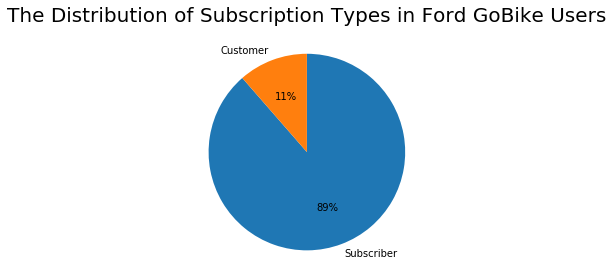

```python
sorted_counts = df_1['user_type'].value_counts()
plt.pie(sorted_counts, labels = sorted_counts.index, autopct='%1.0f%%', startangle=90, counterclock = False)
plt.title("The Distribution of Subscription Types in Ford GoBike Users", fontsize=20, y=1.07)
plt.axis('square');
```

The winter months have the fewest rides. The number of rides continues upwards throughout spring and summer, with the most popular being October. Then, the frequency of rides goes back down again.

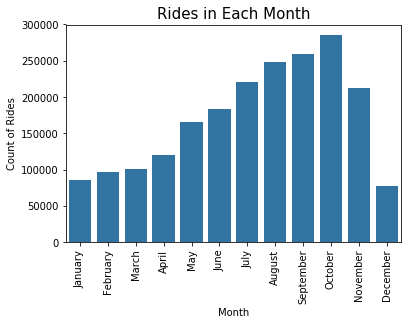

```python
base_color = sb.color_palette()[0]

category_order = ['January', 'February', 'March', 'April', 'May', 'June', 'July', 'August',
                 'September', 'October', 'November', 'December']
sb.countplot(data = df_1, x = 'start_time_month_name', order = category_order, color = base_color)
plt.title('Rides in Each Month', fontsize = 15)
plt.xlabel('Month')
plt.ylabel('Count of Rides')
plt.xticks(rotation = 90);
```

The rides are most frequent on Tuesday, Wednesday, and Thursday, followed by Monday and Friday. Saturday and Sunday are the least popular days.

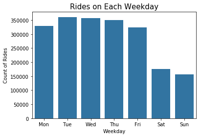

```python
cat_order = ['Mon', 'Tue', 'Wed', 'Thu', 'Fri', 'Sat', 'Sun']
sb.countplot(data = df_1, x = 'start_time_weekday', order = cat_order, color = base_color)
plt.title('Rides on Each Weekday', fontsize = 15)
plt.xlabel('Weekday')
plt.ylabel('Count of Rides');
```

## Bivariate Exploration

This analysis is quite illuminating as it shows that subscribers predominately use the ride service on Monday through Friday, while customers ride the most on the weekends. This is most likely due to subscribers using the service to commute to work, while customers use the bikes on an occasional basis for something unusual in their schedule.

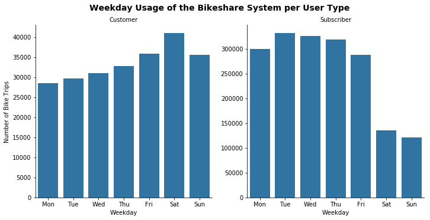

```python
cat_order = ['Mon', 'Tue', 'Wed', 'Thu', 'Fri', 'Sat', 'Sun']
g = sb.catplot(data=df_1, x='start_time_weekday', col="user_type", kind='count', sharey = False, order = cat_order, color = base_color)
g.set_axis_labels("Weekday", "Number of Bike Trips")
g.set_titles("{col_name}")
g.fig.suptitle('Weekday Usage of the Bikeshare System per User Type', y=1.03, fontsize=14, fontweight='semibold');
```

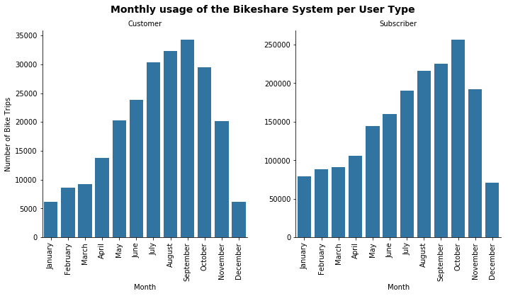

```python
category_order = ['January', 'February', 'March', 'April', 'May', 'June', 'July', 'August',
                 'September', 'October', 'November', 'December']
g = sb.catplot(data=df_1, x='start_time_month_name', col="user_type", kind='count', order=category_order, sharex = True, sharey = False,
            color = base_color)
g.set_axis_labels("Month", "Number of Bike Trips")
g.set_titles("{col_name}")
g.fig.suptitle('Monthly usage of the Bikeshare System per User Type', y=1.03, fontsize=14, fontweight='semibold')
g.set_xticklabels(rotation=90);
```

The bar chart demonstrates that on average, customers take longer rides than subscribers. The mean for customers is 1.513KM, and the mean for subscribers is 1.362KM.

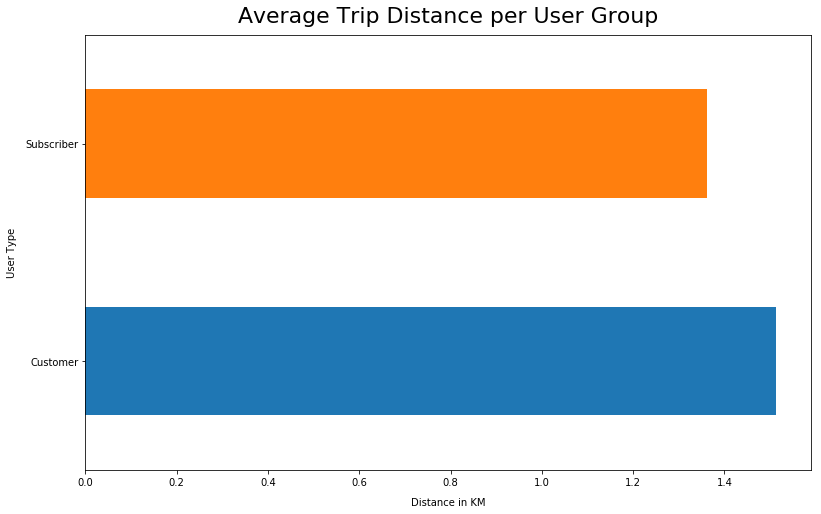

```python
ax = df_1.groupby('user_type')['distance_km'].mean().plot(kind='barh', figsize=(13,8))
ax.set_title('Average Trip Distance per User Group', fontsize=22, y=1.015)
ax.set_ylabel('User Type', labelpad=8)
ax.set_xlabel('Distance in KM', labelpad=10);
```

It was interesting to observe the different usage behaviors between subscribers and customers. Customers show trends towards being more casual in their usage, as they ride more on the weekends, and subscribers appear to use the service on a Monday-Friday basis. It seems likely that subscribers are using the service to commute to work. However, it was surprising to see that customers, on average, take longer rides than subscribers.

## Multivariate Exploration

While there is less female and other gender usage than male, the trend between customers and subscribers of each gender is similar. Customers of all genders use the service more often on the weekends, while subscribers use the system during the week, predominately.

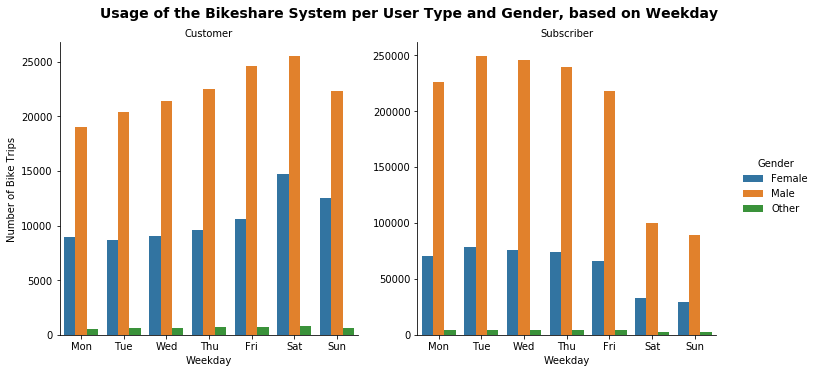

```python
weekday = ['Mon', 'Tue', 'Wed', 'Thu', 'Fri', 'Sat', 'Sun']
g = sb.catplot(data=df_1, x='start_time_weekday', col="user_type", hue='member_gender', kind='count', sharey = False,
                order = weekday)
g.set_axis_labels("Weekday", "Number of Bike Trips")
g._legend.set_title('Gender')
g.set_titles("{col_name}")
g.fig.suptitle('Usage of the Bikeshare System per User Type and Gender, based on Weekday', y=1.03, fontsize=14, fontweight='semibold');
```

Again, we find that each gender follows a similar pattern to the other genders. The winter months are not as popular for customers or subscribers, and usage increases as the summer and fall occur.

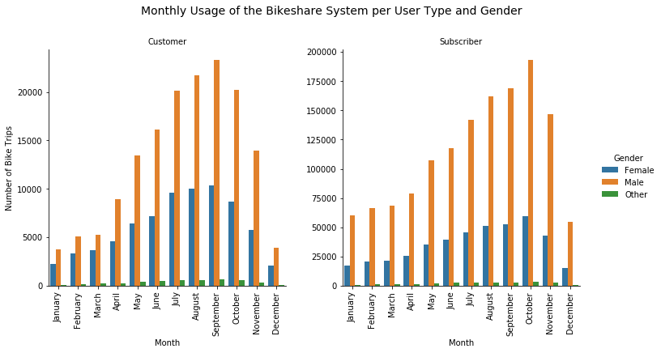

```python
category_order = ['January', 'February', 'March', 'April', 'May', 'June', 'July', 'August',
                 'September', 'October', 'November', 'December']
g = sb.catplot(data=df_1, x='start_time_month_name', col="user_type", hue="member_gender", kind='count', sharey = False, order = category_order)
g.set_axis_labels("Month", "Number of Bike Trips")
g._legend.set_title('Gender')
g.set_titles("{col_name}")
g.fig.suptitle('Monthly Usage of the Bikeshare System per User Type and Gender', y=1.08, fontsize=14)
g.set_xticklabels(rotation=90);
```

Monthly usage during the weekday for customers and subscribers would look interesting as a heatmap. It is easy to visualize the usage in this heatmap, as the darker colors indicate the most rides occuring. The summer and fall are the most popular for both users, and customers prefer the weekend, compared to subscribers.

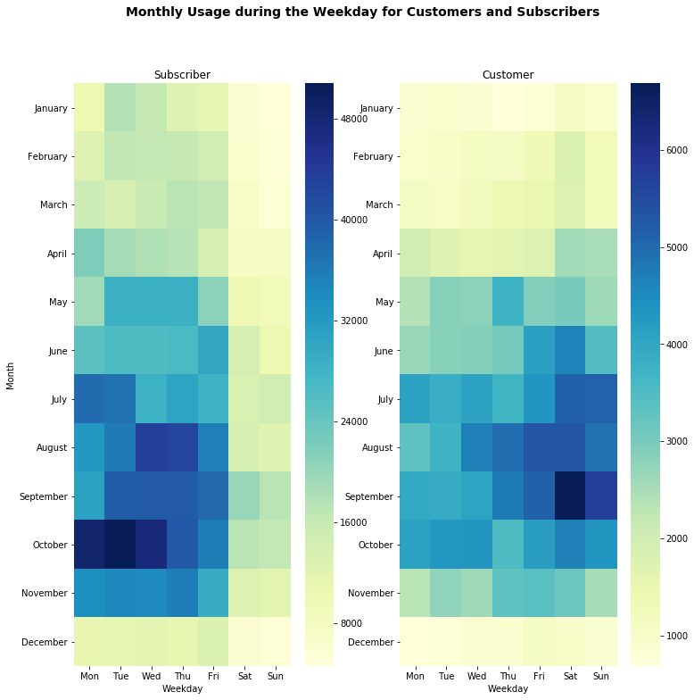

```python
# Setting the weekday order
df_1['start_time_weekday'] = pd.Categorical(df_1['start_time_weekday'],
                                                categories=['Mon','Tue','Wed','Thu','Fri','Sat', 'Sun'],
                                                ordered=True)
df_1['start_time_month_name'] = pd.Categorical(df_1['start_time_month_name'],
                                                categories=['January','February','March', 'April', 'May', 'June', 'July', 'August',
                 'September', 'October', 'November', 'December'],
                                                ordered=True)
plt.figure(figsize=(12,12))
plt.suptitle('Monthly Usage during the Weekday for Customers and Subscribers', fontsize=14, fontweight='semibold')

# heatmap for subscribers
plt.subplot(1, 2, 1)
df_subscriber = df_1.query('user_type == "Subscriber"').groupby(["start_time_month_name", "start_time_weekday"])["bike_id"].size().reset_index()
df_subscriber = df_subscriber.pivot("start_time_month_name", "start_time_weekday", "bike_id")
sb.heatmap(df_subscriber, cmap="YlGnBu")

plt.title("Subscriber", y=1.015)
plt.xlabel('Weekday')
plt.ylabel('Month');
# heatmap for customers
plt.subplot(1, 2, 2)
df_customer = df_1.query('user_type == "Customer"').groupby(["start_time_month_name", "start_time_weekday"])["bike_id"].size().reset_index()
df_customer = df_customer.pivot("start_time_month_name", "start_time_weekday", "bike_id")
sb.heatmap(df_customer, cmap="YlGnBu")


plt.title("Customer", y=1.015)
plt.xlabel('Weekday')
plt.ylabel('');
```

The multivariate charts reinforced the earlier relationships that were observed. The customers prefer to use the Bikeshare on weekends, and the subscribers use the service on Monday-Friday, the most. This was not influenced by gender. The same can be said about usage over the months, as the summer and fall are the most popular usage times, regardless of any other factors.